# Exercise 12.1

The goal here is to create a prediction model for the value of benthic over the Chesepeake bay region.

This prediction model will be graphically portrayed with a:

1. Heatmap
   1. with base plot
   2. wigh `ggplot2` over an actual map
2. Contour plot
   1. with base plot
   2. With `ggplot2` over an actual map
3. 3d Surface plot
   1. with base plot
   2. with a dynamic `plotly` surface plot

# Preamble

## Import Library

The following code will automatically install packages that are not already installed and load them into the library:

```r
if(require('pacman')){
  library('pacman')
}else{
  install.packages('pacman')
  library('pacman')
}
pacman::p_load(sp, EnvStats, gstat, ggplot2, rmarkdown, reshape2, ggmap, RColorBrewer, parallel, dplyr)
```

## Create Assignments

Note that Benthic.df is included in the `EnvStats` package and is not a data frame but an `sp` class, which is very similar to a data frame

```r
#Assignments
benthic <- Benthic.df
lat   <- benthic$Latitude
lon   <- benthic$Longitude
index <- benthic$Index
```

# Inspect the Data Set

```r
head(benthic, 3)
```

|  | Site.ID | Stratum | Latitude | Longitude | Index | Salinity | Silt |
| --- | --- | --- | --- | --- | --- | --- | --- |
| 1 | 89/90-1 | 101 | 38.4430 | -76.4457 | 2.33 | 2.0 | 0.6 |
| 2 | 89/90-1 | 101 | 38.4232 | -76.4237 | 3.67 | 2.0 | 0.8 |
| 3 | 89/90-1 | 101 | 38.4773 | -76.4827 | 2.00 | 1.5 | 0.6 |

# Lattitude and Longitude

- Lattitude is a line that runs east to west that measures how far north of the equatour a location is
  - Lattitude is assigned to the y-axis
- Longitude is a line that runs north to south that measures east/west
  - Longitude is assigned to the x-axis

# Assign the Co-ordinates

The *Benthic* Data set is an `sp` class objects and requires for its co-ordinates to be set:

```r
coordinates(benthic) = ~Longitude + Latitude
```

# Preliminary Step: Create a krige prediction Model

In order to create a krige prediction model two things are required:

- Fitted Variogram Model (e.g. an exponential model)
- A domain values over which to predict values

## Create a variogram Model

### Create a Variogram

If a 4th degree polynomial model was used to model the benthic values over space, a variogram can be made from that model thusly:

(The quadratic model is a required parameter of the kriging process, in exercise 12.2 a quadratic model will be used, the spacific mathematics of this though is somewhat beyond me)

```r
x <- lon
y <- lat
benthic.vg <- variogram(object = index ~
                          x + y +
                          x^2 + x*y + y^2 +
                          x^3 + x^2*y + x*y^2 + y^3 +
                          x^4 + x^3*y + x^2*y^2 + x*y^3 + y^4,
                        data = benthic)
head(benthic.vg)
```

```
    np       dist     gamma dir.hor dir.ver   id
1 4545 0.02410565 0.8506164       0       0 var1
2 4149 0.06703996 0.9393502       0       0 var1
3 3883 0.11396396 1.1513831       0       0 var1
4 4023 0.16138943 1.4599238       0       0 var1
5 5963 0.20615519 1.5641015       0       0 var1
6 6732 0.24983031 1.8992994       0       0 var1
```

### Fit an exponential model to that variogram

```r
benthic.vg.fit.exp <- fit.variogram(benthic.vg, model=vgm(1,"Exp", 0.5,1))
```

Thus the variogram model needed for the krige prediction has been ascertained

## Create a Grid of Domain values to use as predictor values

### Create a sequence of incrementally increasing for the X and Y axis

This will essentially act as the resolution of the overlay, Most monitors are about 140 ppi, hence assuming the plot will be a 9 inch square, about 800 x 800 pixels should look right, but 200 x 200 will be the used due to performance.

```r
xgrid       <-  seq(min(lon), max(lon), length.out = 200)
ygrid       <-  seq(min(lat), max(lat), length.out = 200)
```

### Combine into a domain base

This domain base however has to be a spatial object, this can be acheived by defining co-ordinates in the data frame

```r
xy.surface  <- expand.grid(lon = xgrid, lat = ygrid)
coordinates(xy.surface) = ~lon + lat
head(xy.surface, 3)
```

[output not shown]

## Create the Krige prediction object

```r
benthic.pred <- krige(formula = Index ~1,
                           locations =  benthic,
                           newdata = xy.surface,
                           model= benthic.vg.fit.exp)
```

```
[using ordinary kriging]
```

```r
head(benthic.pred)
```

```
class       : SpatialPointsDataFrame
features    : 6
extent      : -77.3157, -77.28013, 38.0018, 38.0018  (xmin, xmax, ymin, ymax)
coord. ref. : NA
variables   : 2
names       :        var1.pred,         var1.var
min values  : 3.12118704456262, 2.29623742979447
max values  : 3.14485115010402, 2.32162957155164
```

Now there is a prediction model, if that prediction model is extrapolated over our domain (`xy.surface`) the various plots can be created

# Part 1: Create a heatmap

In order to create a heatmap, it is first necessary to take the `sp` prediction object and make it into pixel data, otherwise the heatmap won’t look quite right:

```r
class(benthic.pred)
```

```
[1] "SpatialPointsDataFrame"
attr(,"package")
[1] "sp"
```

```r
gridded(benthic.pred) = TRUE
class(benthic.pred)
```

```
[1] "SpatialPixelsDataFrame"
attr(,"package")
[1] "sp"
```

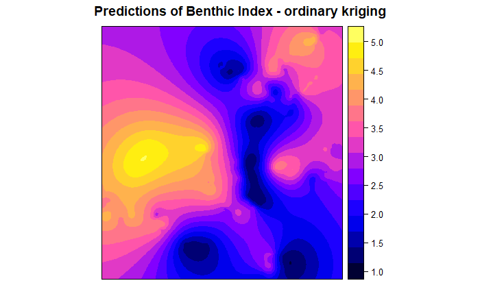

```r
spplot(benthic.pred["var1.pred"],main="Predictions of Benthic Index - ordinary kriging")
```

## Create it in ggplot2

First it is necessary to create a data frame from the `sp` object:

```r
benthic.pred.df      <- cbind(benthic.pred@coords, benthic.pred@data)
benthic.pred.df.tidy <- melt(benthic.pred.df)
head(benthic.pred.df)
```

[output not shown]

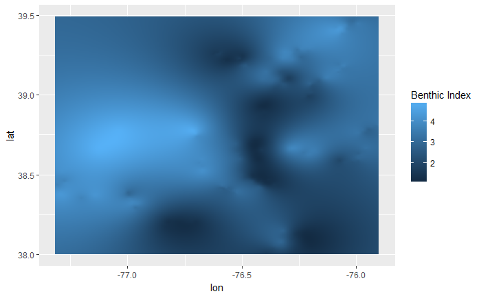

```r
ggplot() +
  geom_tile(data = benthic.pred.df, aes(lon, lat, fill = var1.pred)) +
  labs(fill = "Benthic Index") #
```

This plot would be easier to read if it had discrete intervals rather than a continuous scale:

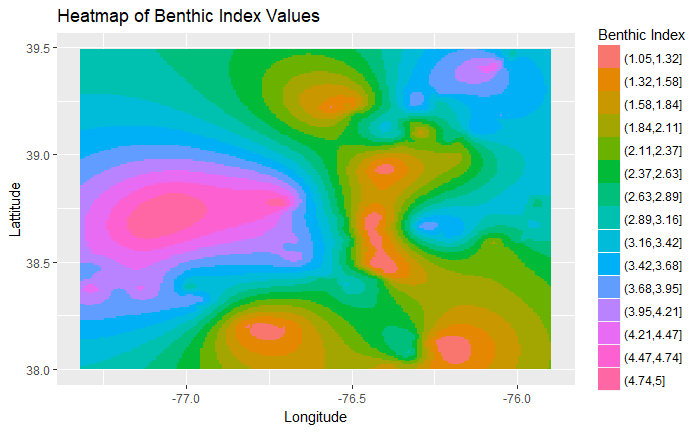

```r
benthic.pred.df$bin <- cut(benthic.pred.df$var1.pred,
                            breaks = as.vector(seq(from = 0, to = 5, length.out = 20)))
ggplot() +
  geom_tile(data = benthic.pred.df, aes(lon, lat, fill = bin)) +
  labs(fill = "Benthic Index",
       title = "Heatmap of Benthic Index Values",
       x = "Longitude",
       y = "Lattitude")
```

```r
NA
```

### Map overlay

Now by adjusting the colour scale and opacity, this can be used as an overlay for the map from exercise 10.1:

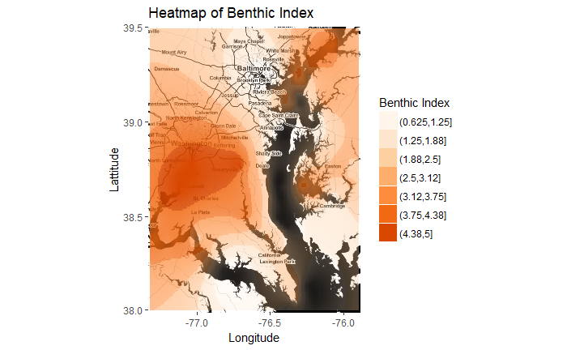

# Part 2: Contour Map

In order to view the surface plot, contours can also be used.

Recall from Week 11/Exercise 10, that contour and surface plots work a little differently to ordinary plots.

A domain grid of equally spaced $x$ and $y$ values is required and a matrix of $z$ values that can be overlayed onto that domain grid in order to provide the surface values required to create the surface plot.

The method from Lecture 10/Wk. 11 involved predicting over the square domain of `xy.surface`, this won’t work here because instead of the `predict` function, the `krige` function was used, hence it is necessary to convert the output from the `krige` function, into the output that would have been given by the predict function, which is the required $z$ surface matrix.

This can be acheived with the `data.matrix` function:

```r
z_surface_matrix <- data.matrix(benthic.pred[1])
```

## Base Package

Using base R packages, a contour plot can be created with the `contour` function:

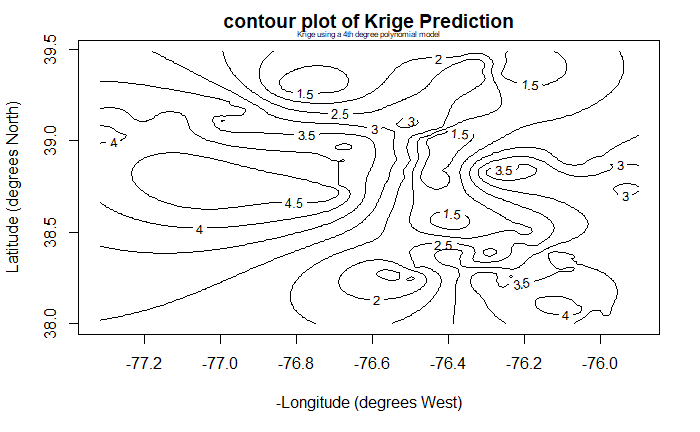

```r
contour(xgrid, ygrid, z_surface_matrix,
          xlab="-Longitude (degrees West)", ylab="Latitude (degrees North)",
          main = "contour plot of Krige Prediction",
          labcex = 0.8)
  mtext("Krige using a 4th degree polynomial model", cex = 0.5)
```

## Using ggplot2

In order to create a contour plot in ggplot 2, it will be necessary to use ‘tidy’ data, which is a table of data such that each column corresponds to a variable:

```r
rownames(z_surface_matrix) <- xgrid
  colnames(z_surface_matrix) <- ygrid
  benthic.pred.melt <- melt(z_surface_matrix,
                            varnames = c("Longitude", "Latitude"),
                            value.name = "Benthic_Index")
  head(benthic.pred.melt)
```

[output not shown]

Observe that this is another way of getting the data frame that was required in part 1 (`benthic.pred.df`), it is included here as another method and for the sake of completion, also it matches the method used in week 10/lecture 11.

Now using ggplot2 a contour plot, can be created:

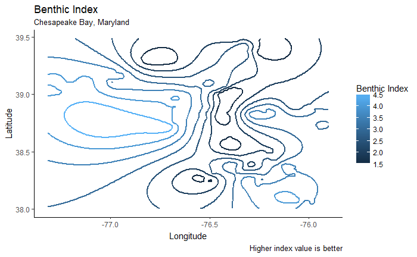

```r
ggplot(data = benthic.pred.melt, aes(x = Longitude,
                                       y = Latitude,
                                       z = Benthic_Index,
                                       colour = ..level..),
         size = 0.5) +
    labs(x = "Longitude", y = 'Latitude',
         title = 'Benthic Index',
         subtitle = "Chesapeake Bay, Maryland",
         caption = "Higher index value is better",
         col = 'Benthic Index', size = 'Benthic Index') +
    geom_contour(lwd = 1) +
  theme_classic()
```

### Map Overlay

The advantage to using ggplot2, is the map overlay can be taken advantage of:

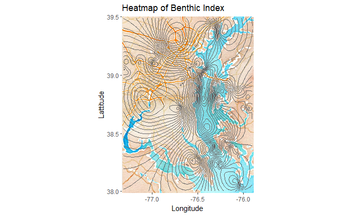

### Map Overlay with Heatmap

This can be combined with the heatmap layer:

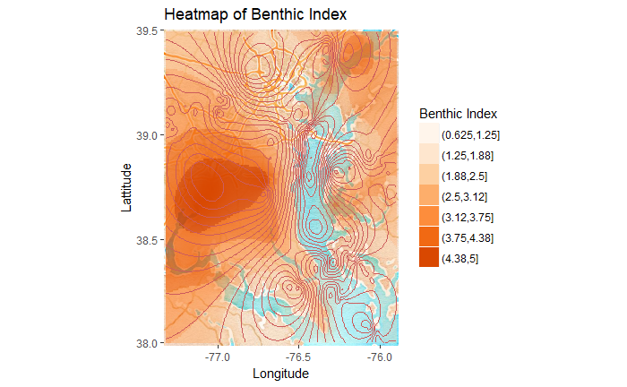

```r
  ggmap(ggmap = map) +
    labs(fill = "Benthic Index",
         x = "Longitude",
         y = "Lattitude",
         title = "Heatmap of Benthic Index") +
    guides(alpha=FALSE) +
    geom_tile(data = benthic.pred.df, aes(lon, lat, fill = bin, alpha = var1.pred)) +
    geom_contour(data = benthic.pred.melt, aes(x = Longitude,
                                               y = Latitude,
                                               z = Benthic_Index),
                col = 'indianred',
                binwidth = 0.2,
                size = 0.6) +
    scale_fill_manual(values = cols)
```